title: “Ensemble Methods” author: “Linh Tran” output: html_document: toc: true

```r
library(ISLR) # for data
library(mlbench) # for data


library(caret)
library(randomForest)  #RF
library(ranger)   #faster implementation of RF algorithm => good for high dimensional dataset

library(gbm)  #boosting (both general and binary)

library(pdp) #partial dependence plot

library(pROC)
```

# Regression

Predict a baseball player’s salary on the basis of various statistics associated with performance in the previous year.

```r
data(Hitters)
Hitters <- na.omit(Hitters)

set.seed(2021)
trRows <- createDataPartition(Hitters$Salary,
                              p = .75,
                              list = F)
```

## Bagging and Random forests

The function `randomForest()` implements Breiman’s random forest algorithm (based on Breiman and Cutler’s original Fortran code) for classification and regression. `ranger()` is a fast implementation of Breiman’s random forests, particularly suited for high dimensional data.

Bagging is a special case of RF if m = p

```r
set.seed(1)
bagging <- randomForest(Salary ~ . ,
                        Hitters,
                        subset = trRows,
                        mtry = 19)  #number of predictors
#another argument: nodesize = min of obs within each terminal node default = 5, for classification default = 1 => growing very large tree by default

set.seed(1)
rf <- randomForest(Salary ~ . ,
                   Hitters,
                   subset = trRows,
                   mtry = 6)   #default mtry = p/3

# fast implementation
set.seed(1)
rf2 <- ranger(Salary ~ . ,
              Hitters[trRows,],
              mtry = 6)
#argument `min.node.size`

pred.rf <- predict(rf, newdata = Hitters[-trRows,]) #predict rf, output is vector
pred.rf2 <- predict(rf2, data = Hitters[-trRows,])$predictions #predict ranger, output is list => has to extract predictions using dollar sign then it will be vector
#caret: predict.train

RMSE(pred.rf, Hitters$Salary[-trRows])
```

```
## [1] 280.28
```

```r
RMSE(pred.rf2, Hitters$Salary[-trRows])
```

```
## [1] 282.4317
```

## Boosting

We first fit a gradient boosting model with Gaussian loss function. Boosting has more tuning parameters and is more sensitive to model training => has to trian model more carefully.

```r
set.seed(1)

#`gbm` package

bst <- gbm(Salary ~ . ,
           Hitters[trRows,],
           distribution = "gaussian", #for regression
           n.trees = 5000, #B
           interaction.depth = 3, #d = 1 by default
           shrinkage = 0.005, #lambda
           cv.folds = 10, #cv determines optimal n.trees
           n.cores = 2)
# bag.fraction = 0.5: 50% of training data is used to grow trees
```

We plot loss function as a result of number of trees added to the ensemble.

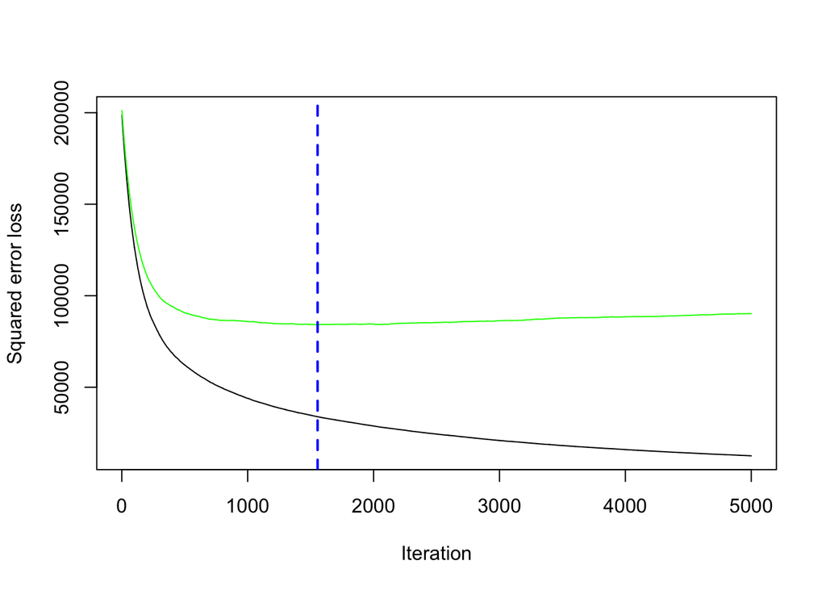

```
## [1] 1555
```

```r
gbm.perf(bst, method = "cv")
```

```r
# x-axis = B (number of iteration), up to 5000
# 2 curves: 1 is training error (black), 1 is cv error (green). Select B that gives smallest cv error. = 1555
```

## Grid search using `caret`

We use the fast implementation of random forest when tuning the model.

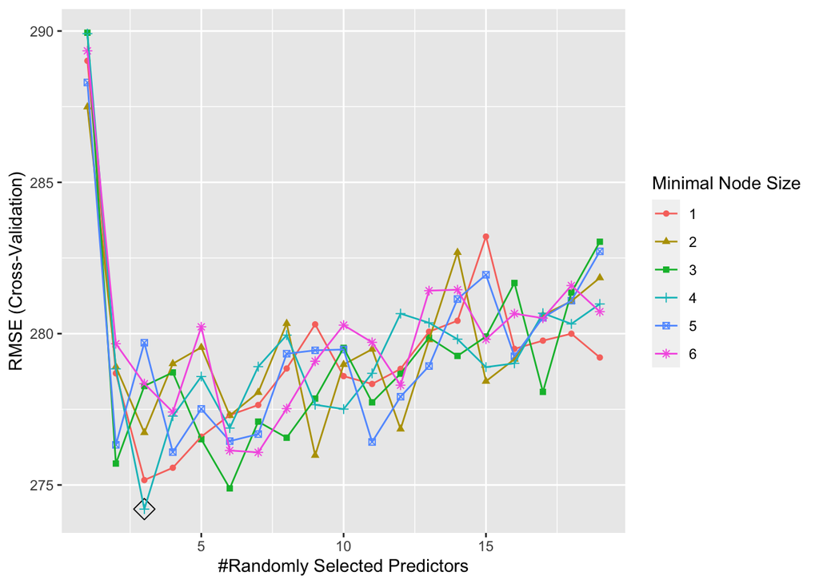

```r
ctrl <- trainControl(method = "cv")

# Try more if possible
rf.grid <- expand.grid(mtry = 1:19, #number of selected variable at each split
                       splitrule = "variance",
                       min.node.size = 1:6) # min terminal node size, can try higher

set.seed(1)
rf.fit <- train(Salary ~ . ,
                Hitters[trRows,],
                method = "ranger",
                tuneGrid = rf.grid,
                trControl = ctrl)

ggplot(rf.fit, highlight = TRUE)
```

```r
rf.fit$bestTune #extract using besttune from train object
```

```
##    mtry splitrule min.node.size
## 16    3  variance             4
```

We then tune the `gbm` model.Tuning more parameters:

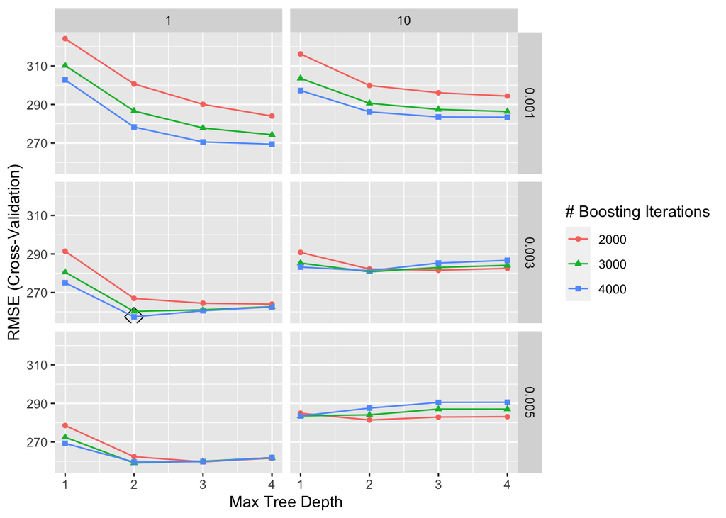

```r
# Try more
gbm.grid <- expand.grid(n.trees = c(2000,3000,4000), #B
                        interaction.depth = 1:4, #d
                        shrinkage = c(0.001,0.003,0.005),  #lambda
                        n.minobsinnode = c(1,10))  #in caret used as tuning parameter


set.seed(1)
gbm.fit <- train(Salary ~ . ,
                 Hitters[trRows,],
                 method = "gbm",
                 tuneGrid = gbm.grid,
                 trControl = ctrl,
                 verbose = FALSE)

ggplot(gbm.fit, highlight = TRUE)
```

```r
# n.minobsinnode = 1 works better
```

It takes a while to train the `gbm` even with a rough tuning grid. The `xgboost` package provides an efficient implementation of gradient boosting framework (approximately 10x faster than `gbm`). You can find much useful information here: https://github.com/dmlc/xgboost/tree/master/demo.

Compare the cross-validation performance. You can also compare with other models that we fitted before.

```r
resamp <- resamples(list(rf = rf.fit, gbm = gbm.fit))
summary(resamp)
```

```
##
## Call:
## summary.resamples(object = resamp)
##
## Models: rf, gbm
## Number of resamples: 10
##
## MAE
##          Min.  1st Qu.   Median     Mean  3rd Qu.     Max. NA's
## rf   98.74629 151.8985 161.5200 174.6345 210.0056 229.1887    0
## gbm 112.18116 160.8835 174.8453 173.8899 196.4601 223.2946    0
##
## RMSE
##         Min.  1st Qu.   Median     Mean  3rd Qu.     Max. NA's
## rf  149.0397 230.0978 264.7041 274.2023 302.1390 424.2364    0
## gbm 160.6428 217.0298 254.0741 257.4122 273.6228 414.0984    0
##
## Rsquared
##          Min.   1st Qu.  Median      Mean   3rd Qu.      Max. NA's
## rf  0.3690611 0.5225075 0.64026 0.6333335 0.7408358 0.8476320    0
## gbm 0.4054759 0.5738089 0.73148 0.6643929 0.7661516 0.8556462    0
```

```r
#gbm gives smaller error
```

## Global interpretation

### Variable importance

We can extract the variable importance from the fitted models. In what follows, the first measure is computed from permuting OOB data. The second measure is the total decrease in node impurities from splitting on the variable, averaged over all trees. For regression, node impurity is measured by residual sum of squares.

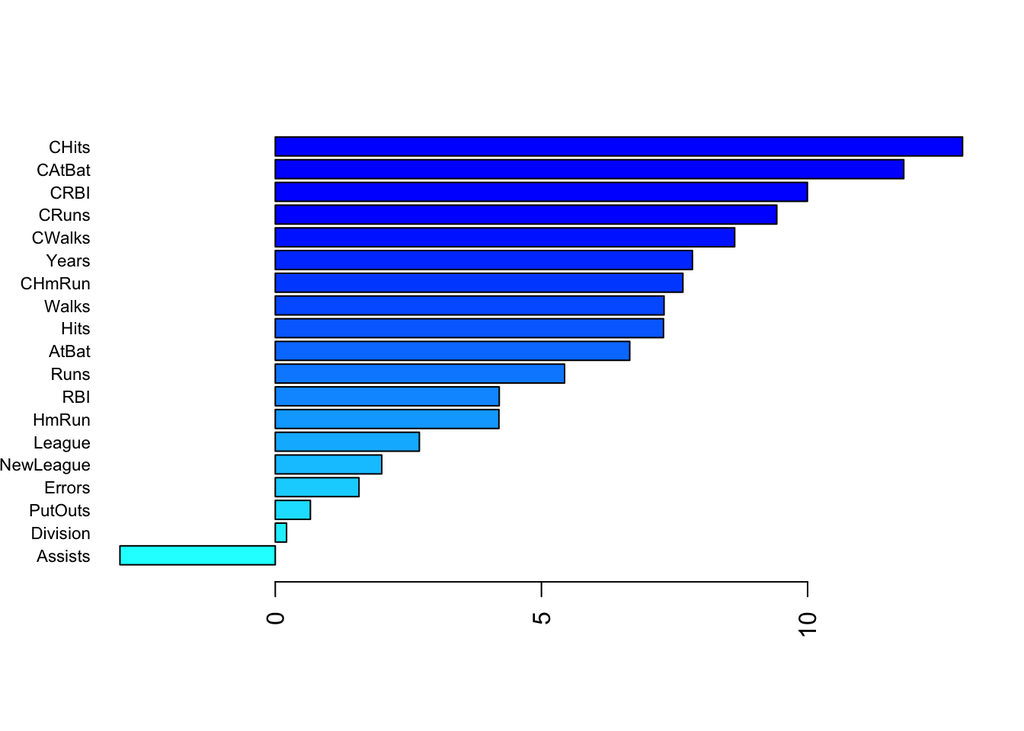

```r
set.seed(1)
rf2.final.per <- ranger(Salary ~ . ,
                        Hitters[trRows,],
                        mtry = rf.fit$bestTune[[1]],
                        splitrule = "variance",
                        min.node.size = rf.fit$bestTune[[3]],
                        importance = "permutation",
                        scale.permutation.importance = TRUE)

barplot(sort(ranger::importance(rf2.final.per), decreasing = FALSE),
        las = 2, horiz = TRUE, cex.names = 0.7,
        col = colorRampPalette(colors = c("cyan","blue"))(19))
```

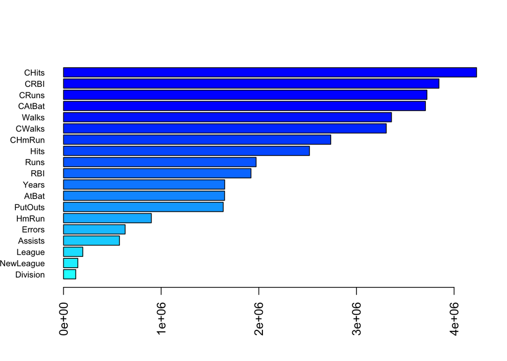

```r
set.seed(1)
rf2.final.imp <- ranger(Salary ~ . ,
                        Hitters[trRows,],
                        mtry = rf.fit$bestTune[[1]],
                        splitrule = "variance",
                        min.node.size = rf.fit$bestTune[[3]],
                        importance = "impurity")

barplot(sort(ranger::importance(rf2.final.imp), decreasing = FALSE),
        las = 2, horiz = TRUE, cex.names = 0.7,
        col = colorRampPalette(colors = c("cyan","blue"))(19))
```

Variable importance from boosting can be obtained using the `summary()` function.

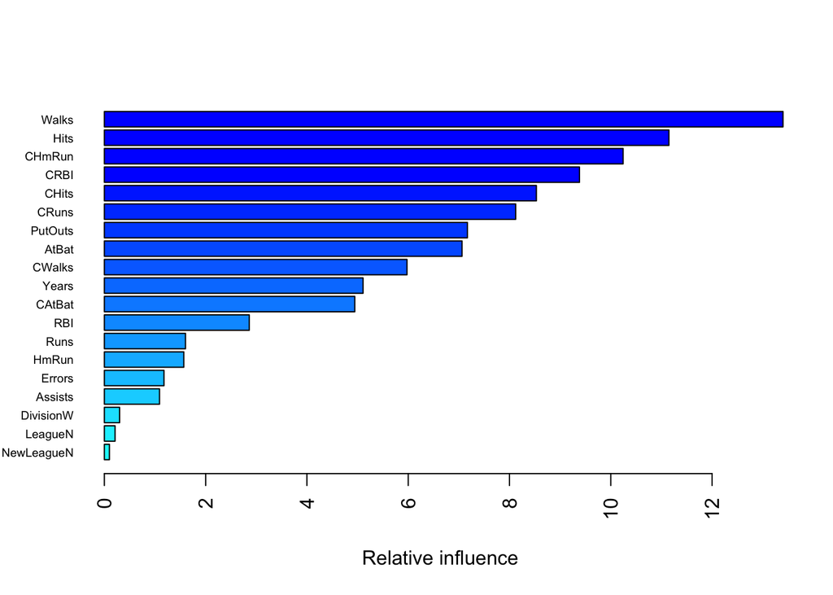

```
##                   var     rel.inf
## Walks           Walks 13.40112263
## Hits             Hits 11.14833444
## CHmRun         CHmRun 10.24374651
## CRBI             CRBI  9.38212292
## CHits           CHits  8.53104072
## CRuns           CRuns  8.12184366
## PutOuts       PutOuts  7.16956645
## AtBat           AtBat  7.06299890
## CWalks         CWalks  5.97573320
## Years           Years  5.10808149
## CAtBat         CAtBat  4.94507359
## RBI               RBI  2.86161671
## Runs             Runs  1.60242284
## HmRun           HmRun  1.56861862
## Errors         Errors  1.17712846
## Assists       Assists  1.08939060
## DivisionW   DivisionW  0.30044598
## LeagueN       LeagueN  0.21104846
## NewLeagueN NewLeagueN  0.09966381
```

```r
summary(gbm.fit$finalModel, las = 2, cBars = 19, cex.names = 0.6)
```

### Partial dependence plots

After the most relevant variables have been identified, the next step is to attempt to understand how the response variable changes based on these variables. For this we can use partial dependence plots (PDPs).

PDPs plot the change in the average predicted value as specified feature(s) vary over their marginal distribution. The PDP plot below displays the average change in predicted `Salary` as we vary `CRBI` while holding all other variables constant. This is done by holding all variables constant for each observation in our training data set but then apply the unique values of `CRBI` for each observation. We then average the `Salary` across all the observations.

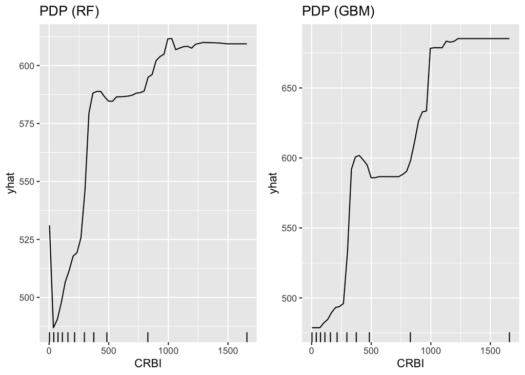

```r
p1 <- partial(rf.fit, pred.var = "CRBI",
              plot = TRUE, rug = TRUE,
              plot.engine = "ggplot") + ggtitle("PDP (RF)")
p2 <- partial(gbm.fit, pred.var = "CRBI",
              plot = TRUE, rug = TRUE,
              plot.engine = "ggplot") + ggtitle("PDP (GBM)")
grid.arrange(p1, p2, nrow = 1)
```

# Classification

We use the Pima Indians Diabetes Database for illustration. The data contain 768 observations and 9 variables. The outcome is a binary variable `diabetes`.

```r
data(PimaIndiansDiabetes)
dat <- PimaIndiansDiabetes
dat$diabetes <- factor(dat$diabetes, c("pos", "neg"))

set.seed(1)
rowTrain <- createDataPartition(y = dat$diabetes,
                                p = 2/3,
                                list = FALSE)
```

## Bagging and random forests

```r
set.seed(1)
bagging <- randomForest(diabetes ~ . ,
                        dat[rowTrain,],
                        mtry = 8)

set.seed(1)
rf <- randomForest(diabetes ~ . ,
                   dat[rowTrain,],
                   mtry = 3)

set.seed(1)
rf2 <- ranger(diabetes ~ . ,
              dat[rowTrain,],
              mtry = 3,
              probability = TRUE)

rf.pred <- predict(rf, newdata = dat[-rowTrain,], type = "prob")[,1]
rf2.pred <- predict(rf2, data = dat[-rowTrain,], type = "response")$predictions[,1]
```

## Boosting

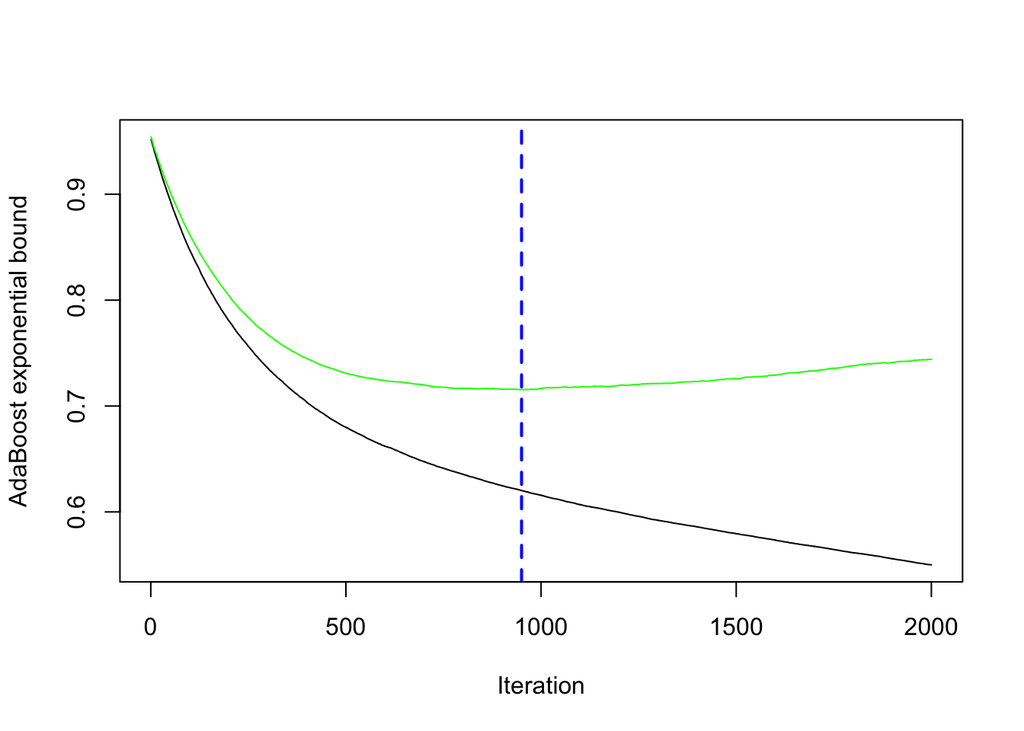

```
## [1] 950
```

```r
dat2 <- dat
dat2$diabetes <- as.numeric(dat$diabetes == "pos")

set.seed(1)
bst <- gbm(diabetes ~ . ,
           dat2[rowTrain,],
           distribution = "adaboost",
           n.trees = 2000,
           interaction.depth = 2,
           shrinkage = 0.005,
           cv.folds = 10,
           n.cores = 2)

gbm.perf(bst, method = "cv")
```

## Grid search using `caret`

### Random forests

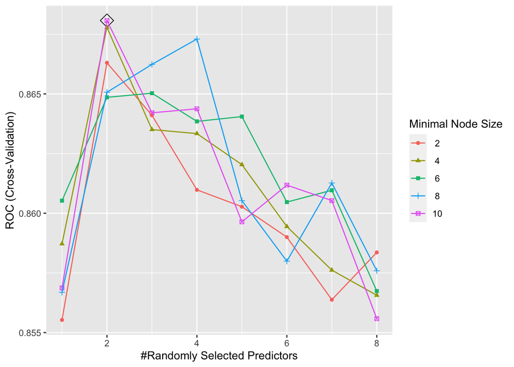

```r
ctrl <- trainControl(method = "cv",
                     classProbs = TRUE,
                     summaryFunction = twoClassSummary)

rf.grid <- expand.grid(mtry = 1:8,
                       splitrule = "gini",
                       min.node.size = seq(from = 2, to = 10, by = 2))
set.seed(1)
rf.fit <- train(diabetes ~ . ,
                dat,
                subset = rowTrain,
                method = "ranger",
                tuneGrid = rf.grid,
                metric = "ROC",
                trControl = ctrl)

ggplot(rf.fit, highlight = TRUE)
```

```r
rf.pred <- predict(rf.fit, newdata = dat[-rowTrain,], type = "prob")[,1]
```

### AdaBoost

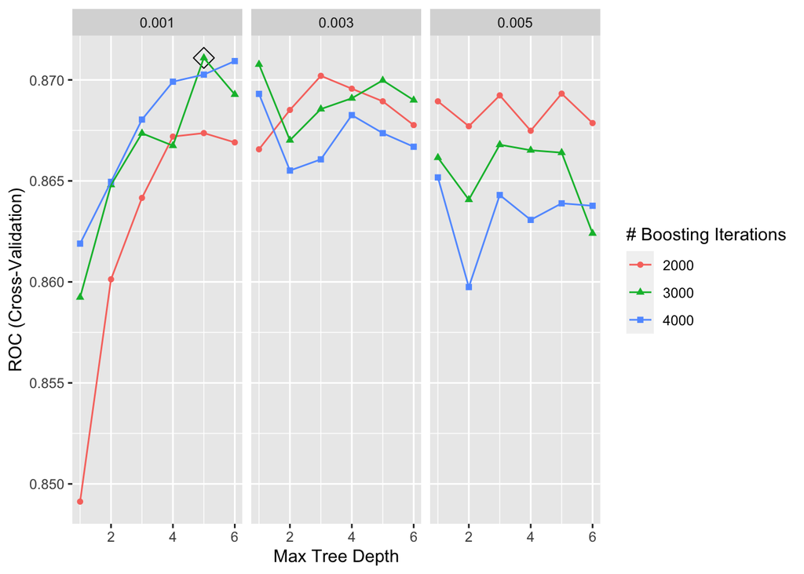

```r
gbmA.grid <- expand.grid(n.trees = c(2000,3000,4000),
                         interaction.depth = 1:6,
                         shrinkage = c(0.001,0.003,0.005),
                         n.minobsinnode = 1)
set.seed(1)
gbmA.fit <- train(diabetes ~ . ,
                  dat,
                  subset = rowTrain,
                  tuneGrid = gbmA.grid,
                  trControl = ctrl,
                  method = "gbm",
                  distribution = "adaboost",
                  metric = "ROC",
                  verbose = FALSE)

ggplot(gbmA.fit, highlight = TRUE)
```

```r
gbmA.pred <- predict(gbmA.fit, newdata = dat[-rowTrain,], type = "prob")[,1]
```

```r
resamp <- resamples(list(rf = rf.fit,
                         gbmA = gbmA.fit))
summary(resamp)
```

```
##
## Call:
## summary.resamples(object = resamp)
##
## Models: rf, gbmA
## Number of resamples: 10
##
## ROC
##           Min.   1st Qu.    Median      Mean   3rd Qu.      Max. NA's
## rf   0.7946128 0.8307338 0.8451178 0.8680741 0.9048822 0.9636678    0
## gbmA 0.8181818 0.8295083 0.8582393 0.8710901 0.9111953 0.9509804    0
##
## Sens
##           Min.   1st Qu.    Median      Mean   3rd Qu.      Max. NA's
## rf   0.5000000 0.6111111 0.6388889 0.6650327 0.7181373 0.8333333    0
## gbmA 0.3888889 0.5555556 0.6111111 0.6261438 0.7181373 0.8888889    0
##
## Spec
##           Min.   1st Qu.    Median      Mean   3rd Qu.      Max. NA's
## rf   0.7272727 0.8308824 0.8939394 0.8709447 0.9318182 0.9705882    0
## gbmA 0.7575758 0.8594029 0.9255793 0.9009804 0.9625668 0.9705882    0
```

## Global interpretation

### Variable importance

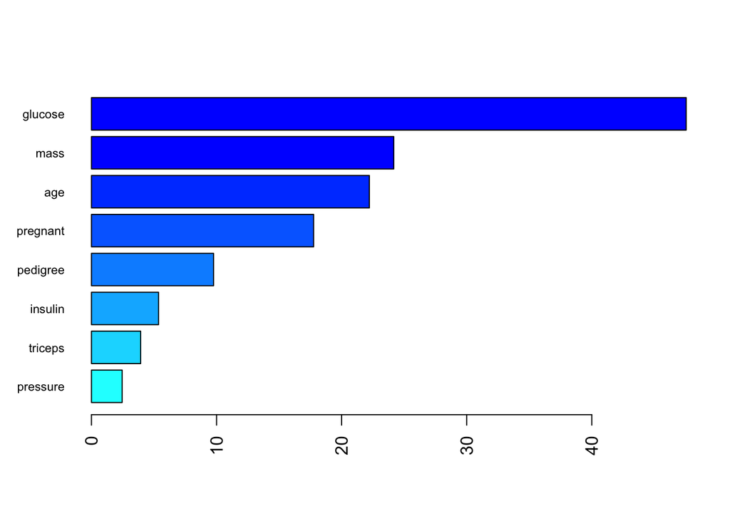

```r
set.seed(1)
rf2.final.per <- ranger(diabetes ~ . ,
                        dat[rowTrain,],
                        mtry = rf.fit$bestTune[[1]],
                        min.node.size = rf.fit$bestTune[[3]],
                        splitrule = "gini",
                        importance = "permutation",
                        scale.permutation.importance = TRUE)

barplot(sort(ranger::importance(rf2.final.per), decreasing = FALSE),
        las = 2, horiz = TRUE, cex.names = 0.7,
        col = colorRampPalette(colors = c("cyan","blue"))(8))
```

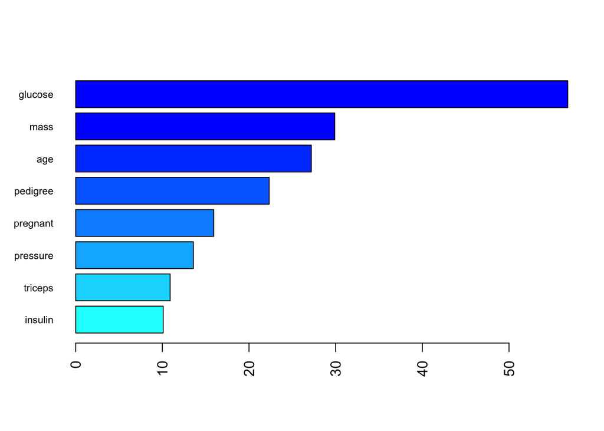

```r
set.seed(1)
rf2.final.imp <- ranger(diabetes ~ . , dat[rowTrain,],
                        mtry = rf.fit$bestTune[[1]],
                        splitrule = "gini",
                        min.node.size = rf.fit$bestTune[[3]],
                        importance = "impurity")

barplot(sort(ranger::importance(rf2.final.imp), decreasing = FALSE),
        las = 2, horiz = TRUE, cex.names = 0.7,
        col = colorRampPalette(colors = c("cyan","blue"))(8))
```

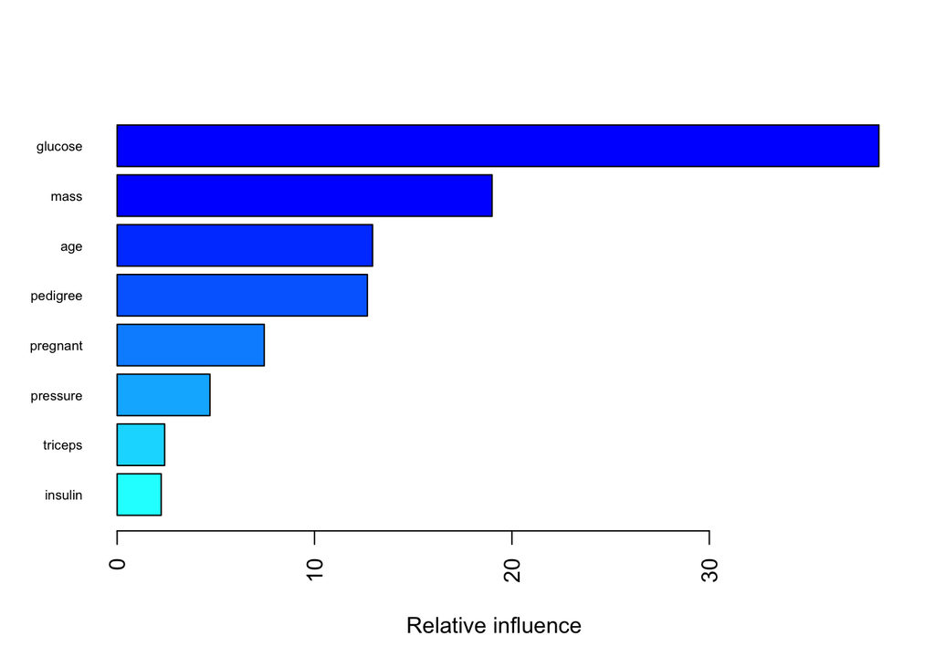

```
##               var   rel.inf
## glucose   glucose 38.592321
## mass         mass 18.996714
## age           age 12.942254
## pedigree pedigree 12.678471
## pregnant pregnant  7.450772
## pressure pressure  4.701505
## triceps   triceps  2.406526
## insulin   insulin  2.231438
```

```r
summary(gbmA.fit$finalModel, las = 2, cBars = 19, cex.names = 0.6)
```

### PDP

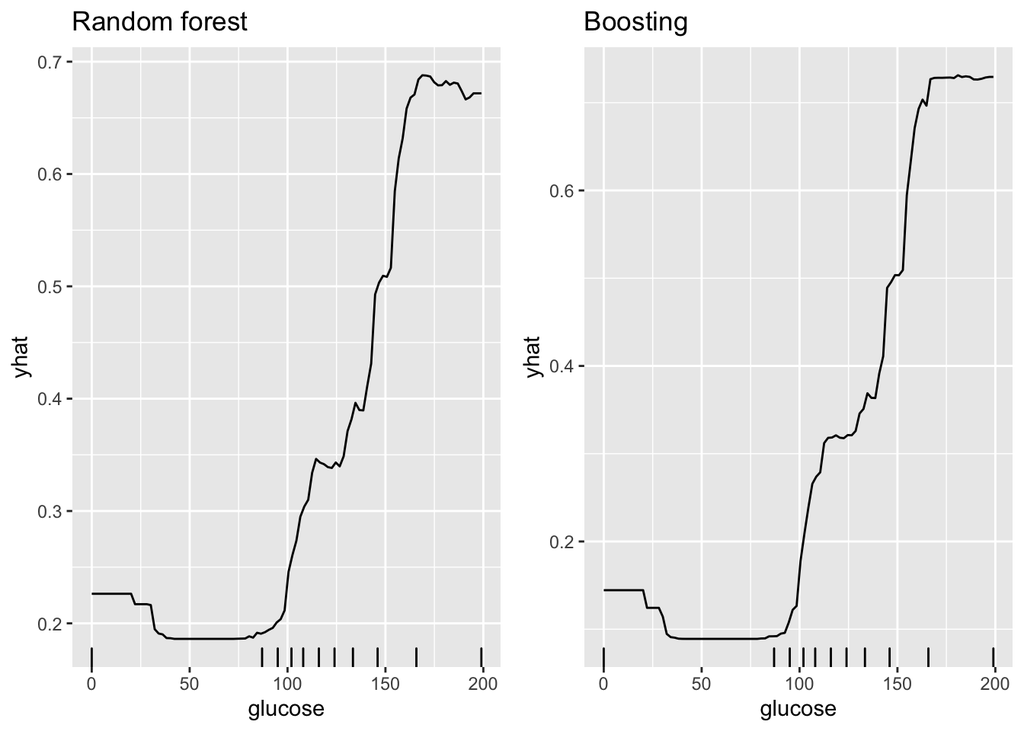

```r
pdp.rf <- rf.fit %>%
  partial(pred.var = "glucose",
          grid.resolution = 100,
          prob = TRUE) %>%
  autoplot(rug = TRUE, train = dat[rowTrain,]) +
  ggtitle("Random forest")

pdp.gbm <- gbmA.fit %>%
  partial(pred.var = "glucose",
          grid.resolution = 100,
          prob = TRUE) %>%
  autoplot(rug = TRUE, train = dat[rowTrain,]) +
  ggtitle("Boosting")

grid.arrange(pdp.rf, pdp.gbm, nrow = 1)
```

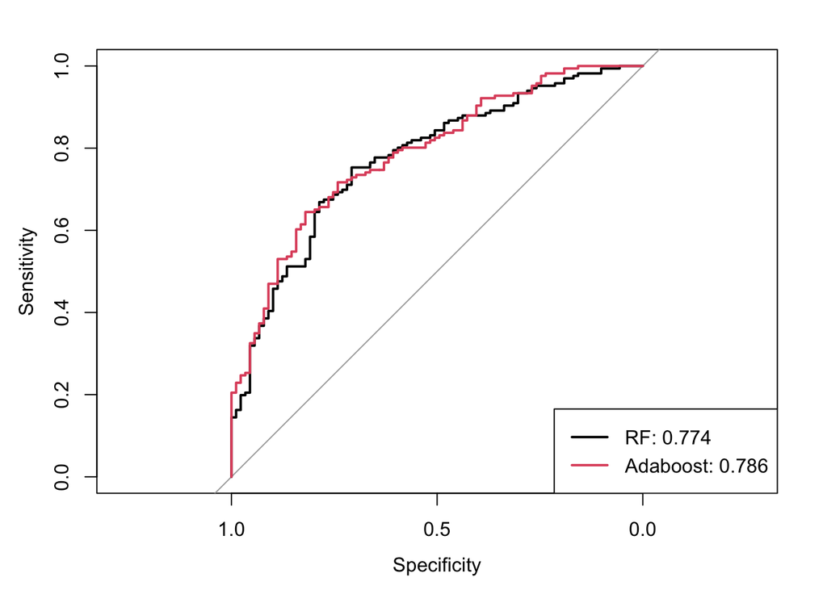

```r
roc.rf <- roc(dat$diabetes[-rowTrain], rf.pred)
roc.gbmA <- roc(dat$diabetes[-rowTrain], gbmA.pred)

plot(roc.rf, col = 1)
plot(roc.gbmA, add = TRUE, col = 2)

auc <- c(roc.rf$auc[1], roc.gbmA$auc[1])

modelNames <- c("RF","Adaboost")
legend("bottomright", legend = paste0(modelNames, ": ", round(auc,3)),
       col = 1:2, lwd = 2)
```